# FIFA19

J.C. Kameni

6/25/2019

[figure not shown]

5 time Ballon D’Or Winner - Cristiano Ronaldo

# Introduction

FIFA 19 is a football simulation video game developed by EA Vancouver as part of Electronic Arts’ FIFA series. Announced on 6 June 2018 for its E3 2018 press conference, it was released on 28 September 2018 for PlayStation 3, PlayStation 4, Xbox 360, Xbox One, Nintendo Switch, and Microsoft Windows. It is the 26th installment in the FIFA series. As with FIFA 18, Cristiano Ronaldo initially as the cover athlete of the regular edition: however, following his unanticipated transfer from Spanish club Real Madrid to Italian side Juventus, new cover art was released, featuring Neymar, Kevin De Bruyne and Paulo Dybala.

The game features the UEFA club competitions for the first time, including the UEFA Champions League and UEFA Europa League. Martin Tyler and Alan Smith return as regular commentators, while the new commentary team of Derek Rae and Lee Dixon feature in the UEFA competitions mode. Composer Hans Zimmer and rapper Vince Staples recorded a new remix of the UEFA Champions League anthem specifically for the game. The character Alex Hunter, who first appeared in FIFA 17 returns for the third and final installment of “The Journey”, entitled, “The Journey: Champions”. In June 2019, a free update added the FIFA Women’s World Cup as a separate game mode.

## Top Leagues

If you are looking to build a solid team, the 12 leagues shown below may be a good place to start. Obviously the quality of your team will depend on several factors, one of them being how much money you’ve got to spend.

```r
# Summary by league

options(scipen = 999)

league_summary <- data %>%
  group_by(League) %>%
  summarise(`Number of Players` = n(),
            `Number of Teams` = n_distinct(Club),
            `Average Player Rating` = round(mean(Overall),2),
            `Median Player Rating` = median(Overall),
            `Minimum Player Rating` = min(Overall),
            `Maximum Player Rating` = max(Overall),
            `Average Player Age` = mean(Age),
            `Average Player Potential` = mean(Potential),
            `Average Player Potential` = round(mean(Potential),2),
            `Average Player Value (€)` = mean(Value),
            `Median Player Value (€)` = median(Value)) %>%
  arrange(desc(`Average Player Rating`))

(league_summary_table <- league_summary%>%
  kable("html", caption = "League Summary Table", align = "l") %>%
  kable_styling(bootstrap_options = c("striped", "hover", "bordered", "responsive"), full_width = T))
```

League Summary Table

| League | Number of Players | Number of Teams | Average Player Rating | Median Player Rating | Minimum Player Rating | Maximum Player Rating | Average Player Age | Average Player Potential | Average Player Value (€) | Median Player Value (€) |
| --- | --- | --- | --- | --- | --- | --- | --- | --- | --- | --- |
| Italian Serie A | 546 | 20 | 73.66 | 74 | 51 | 94 | 25.72161 | 78.20 | 8372033 | 5000000 |
| Spanish Liga | 616 | 20 | 73.24 | 75 | 54 | 94 | 24.72078 | 78.59 | 9437687 | 6000000 |
| English Premier League | 649 | 20 | 72.62 | 75 | 51 | 91 | 24.61171 | 78.42 | 9510108 | 6000000 |
| German Bundesliga | 548 | 18 | 72.30 | 74 | 56 | 90 | 24.16241 | 78.22 | 7393449 | 5000000 |
| French Ligue 1 | 569 | 20 | 71.02 | 72 | 50 | 92 | 24.36204 | 76.70 | 5439745 | 3100000 |
| Brazilian Série A | 300 | 15 | 70.79 | 71 | 62 | 83 | 30.04000 | 70.79 | 2587167 | 1300000 |
| Portuguese Primeira Liga | 482 | 18 | 70.70 | 70 | 53 | 85 | 25.47510 | 74.49 | 3934461 | 1900000 |
| Turkish Süper Lig | 504 | 18 | 68.75 | 70 | 50 | 85 | 26.61310 | 72.36 | 2553353 | 1200000 |
| Argentinian Primera División | 722 | 26 | 67.15 | 67 | 51 | 80 | 25.52493 | 72.62 | 1834134 | 775000 |
| Dutch Eredivisie | 506 | 18 | 66.92 | 67 | 54 | 83 | 23.26680 | 73.02 | 2215109 | 850000 |
| MLS Western Conference | 329 | 12 | 66.52 | 67 | 47 | 85 | 26.11854 | 70.57 | 1578875 | 700000 |
| MLS Eastern Conference | 304 | 11 | 66.50 | 66 | 48 | 82 | 25.39145 | 71.14 | 1795691 | 712500 |
| Other | 12132 | 436 | 64.22 | 65 | 46 | 86 | 25.04402 | 69.40 | 1048304 | 500000 |

## Fatto in Italia

### Ratings Distribution

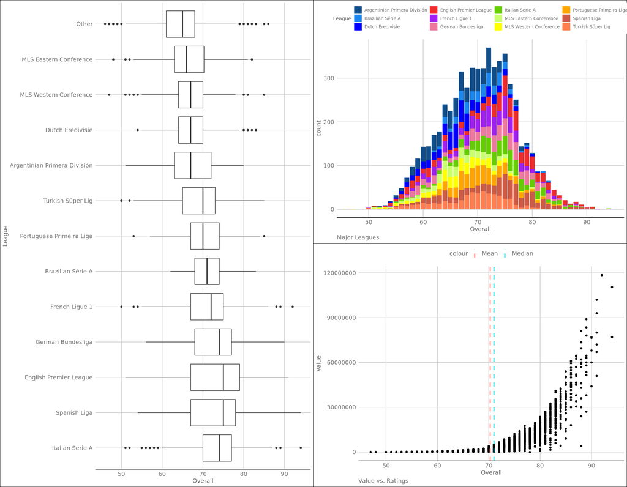

```r
major_league_ratings <- ggplot(top_leagues, aes(Overall, fill = League)) + geom_histogram(stat = 'count') +
  theme_gdocs() +
  scale_fill_manual(values = c("dodgerblue4","dodgerblue2","blue","firebrick2","purple","palevioletred2",
                               "chartreuse3","darkolivegreen1","yellow","orange","coral3","coral")) +
  scale_color_manual(name = "Stats", values = c(Median = "blue", Mean = "red")) +
  theme(legend.position = "top", legend.direction = 'horizontal' , legend.text = element_text(size = 9), legend.title = element_text(size = 10)) +
  labs(caption = 'Major Leagues')


value_vs_ratings <- ggplot(top_leagues, aes(Overall, Value)) +
  geom_point() +
  geom_vline(aes(xintercept = median(Overall), col = 'Median'), linetype = "dashed", size = 1) +
  geom_vline(aes(xintercept = mean(Overall), col = 'Mean'), linetype = "dashed", size = 1) +
  theme_gdocs() +
  labs(caption = "Value vs. Ratings") +
  theme(legend.position = 'top', legend.direction = 'horizontal')


ratings_boxplot <- ggplot(data, aes(x = reorder(League, -Overall), y = Overall)) +
  geom_boxplot() +
  theme_gdocs() +
  coord_flip() +
  theme(legend.position = 'none') +
  xlab("League")
```

### Age Distribution

```r
major_league_age <- ggplot(top_leagues, aes(Age, fill = League)) + geom_histogram(stat = 'count', width = 1) +
  theme_gdocs() +
  scale_fill_manual(values = c("dodgerblue4","dodgerblue2","blue","firebrick2","purple","palevioletred2",
                               "chartreuse3","darkolivegreen1","yellow","orange","coral3","coral")) +
  theme(legend.position = "top", legend.direction = 'horizontal' , legend.text = element_text(size = 8.5), legend.title = element_text(size = 10)) +
  labs(caption = "Major Leagues")

other_leagues_age <- ggplot(top_leagues, aes(Age, Value)) +
  geom_point() +
  geom_vline(aes(xintercept = median(Age), col = 'Median'), linetype = "dashed", size = 1) +
  geom_vline(aes(xintercept = mean(Age), col = 'Mean'), linetype = "dashed", size = 1) +
  scale_color_manual(name = "Stats", values = c(Median = "blue", Mean = "red")) +
  theme_gdocs() +
  labs(caption = "Value vs. Age") +
  theme(legend.position = 'top', legend.direction = "horizontal")

overall_age_distribution <- ggplot(data, aes(x = reorder(League, -Age), y = Age)) +
  geom_boxplot() +
  theme_gdocs() +
  coord_flip() +
  theme(legend.position = 'none') +
  xlab("League")
```

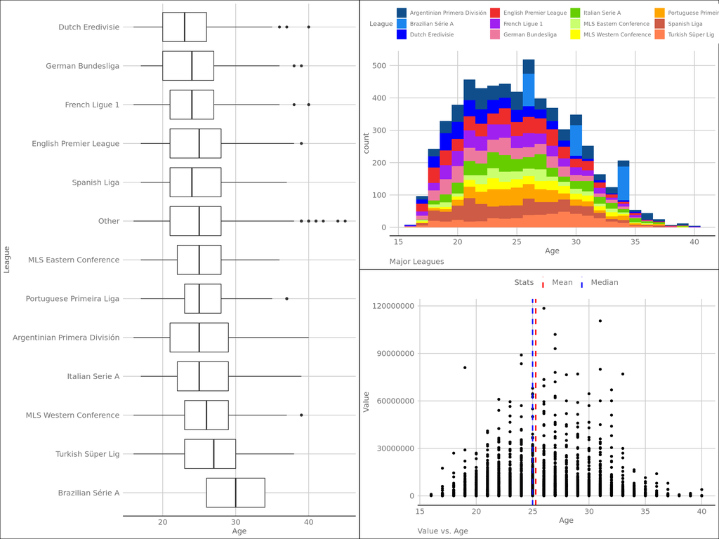

[figure not shown]

[output not shown]

[output not shown]

[figure not shown]

```r
gridExtra::grid.arrange(overall_age_distribution, gridExtra::arrangeGrob(major_league_age, other_leagues_age), ncol =2)
```